# 140.651 - Lab 12

## HW5 Problem 5

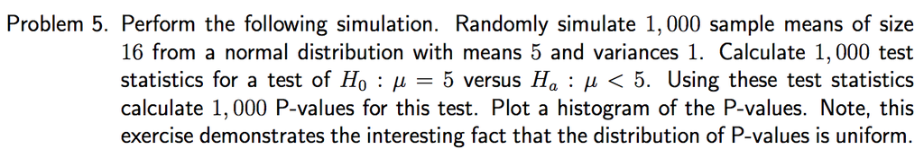

Note, this exercise demonstrates the interesting fact that the distribution of P-values is uniform **when the null hypothesis is true**.

- t-test formulation:

$$\begin{aligned}
H_0: & \mu = \mu_0 \overset{here}{=} 5 \\
H_{1}: & \mu < \mu_0 \overset{here}{=} 5
\end{aligned}$$

- Test statistics:

$$T S = \frac { \overline { X }_n - \mu _ { 0 } } { S / \sqrt { n } } \sim \text{ Student's } t\text{-distribution with }n − 1 \text{ degrees of freedom}$$
In our case: $n=16$.

- Recall: p-value of a test is the probability of seeing a result at least as extreme as the one that we actually observe, assuming the null hypothesis is true. Our result can be summarized as $t$, that is, value of test statistic $TS$ that we have actually observed in our sample data.
- Given we work with one-side t-test, the probability that the result is at least as extreme as the one we observe is

$$P(TS \leq t)$$
which, knowing that $TS \sim \text{ Student's } t\text{-distribution with }n − 1 \text{ degrees of freedom}$, can be computed by evaluating probability function for Student’s $t$-distribution with $n-1$ degrees of freedom.

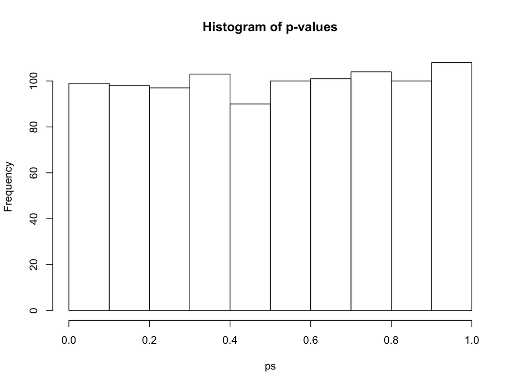

```r
set.seed(123)

## Simulate matrix of 1000 rows and 16 columns
## Each row is sample of 16 random variables from N(5,1)
x <- matrix(rnorm(1000 * 16, mean = 5, sd = 1), nrow = 1000)

## For each out of 1,000 samples, compute mean of 16-element sample
means <- apply(x, 1, mean)

## For each out of 1,000 samples, compute SD of 16-element sample
sds <- apply(x, 1, sd)

## For each out of 1,000 samples, compute value of t
## (t := observed value of a test statistic)
ts <- (means - 5)/(sds/sqrt(16))

## For each out of 1,000 samples, compute P(TS <= t)
## that is, evaluate probability function for
## Student's $t$-distribution with $n-1$ degrees of freedom
ps <- pt(ts, df = 16-1)

## Histogram of obtaines values
hist(ps, main = "Histogram of p-values")
```

- Alternatively, the above could be computed using built-in t-test function

```r
## For each out of 1,000 samples, compute p-value
ps_B <- apply(x, 1, function(x.row) {
  t.test.out <- t.test(x.row, alternative = "less", mu = 5)
  t.test.out$p.value
})

## Check if all elements of vector ps are equal to elements of vector ps_B
all(ps == ps_B)
```

```
## [1] TRUE
```

## HW5 Problem 9

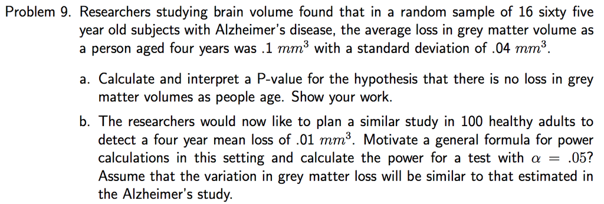

### (a)

We assume loss in grey matter volume in this population is normally distributed.

- t-test formulation:

$$\begin{aligned}
H_0: & \mu = \mu_0 \overset{here}{=} 0 \text{ (no loss in grey matter volumes)}\\
H_{1}: & \mu \neq \mu_0 \overset{here}{=} 0 \text{ (there is loss in grey matter volumes)}
\end{aligned}$$

- Test statistics:

$$T S = \frac { \overline { X }_n - \mu _ { 0 } } { S / \sqrt { n } } \sim \text{ Student's } t\text{-distribution with }n − 1 \text{ degrees of freedom}$$
In our case: $n=16$.

- Given we work with two-side t-test, the probability that the result is at least as extreme as the one we observe is

$$\begin{aligned}
P(TS \geq |t|) + P(TS \leq -|t|) & = 2 \cdot P(TS \geq |t|)
\end{aligned}$$

- We have from data: $\overline { X }_n = 0.1$, $\mu_0 = 0$, $S = 0.04$, $n=16$, hence observed value of test statistic $TS$ is

$$t = \frac{0.1 - 0}{0.04/\sqrt(16)} = 10$$

```r
t <- (0.1) / (0.04 / sqrt(16))
2 * pt(abs(t), df = 16-1, lower.tail = FALSE)
```

```
## [1] 4.996898e-08
```

- Therefore we reject the null hypothesis at singificance level $\alpha= 0.05$ for this population and conclude that there is a statistically significant change in grey matter volume.

### (b)

Relevant lecture notes:

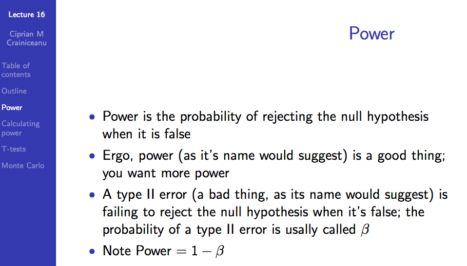

- Consider $\mu_{\alpha}$ – the likely value of true unknown parameter $\mu$ at which we want to evaluate the power; $\mu_{\alpha}$ is chosen subjectively to reflect the likely value of $\mu$ from the researcher’s prior knowledge (following how [this](https://onlinecourses.science.psu.edu/stat500/node/46/) resurce describes it)
- In this problem:

$$\begin{aligned}
\mu_{0} & =0 \\
\mu_{\alpha} & =0.01
\end{aligned}$$

t-test formulation:

$$\begin{aligned}
H_0: & \mu = \mu_0 = 0 \\
H_{\alpha}: & \mu > \mu_0 = 0
\end{aligned}$$

Test statistic:

$$\begin{aligned}
T S = \frac { \overline { X } - \mu _ { 0 } } { S / \sqrt { n } }
\end{aligned}$$
Reject the null hypothesis at significance level $\alpha$ when

$$TS \geq t _ { 1 - \alpha , n - 1 }$$
(or: $TS \geq z _ { 1 - \alpha}$ if it was said that $n$ is quite large).

- Rewriting (in general form for $\mu_{ a }$, and with more steps explained) the lecture notes (Lecture 16, slides 10, 11) we have:

$$\begin{aligned}
\text{power}
& =
P \left( TS > t _ { 1 - \alpha , n - 1 } \left| \right. \mu = \mu _ { a } \right) \\
& =
P \left( \frac { \overline { X } - \mu_0 } { S / \sqrt { n } } > t _ { 1 - \alpha , n - 1 } \left| \right. \mu = \mu _ { a } \right) \\
& =
P \left( \sqrt { n } ( \overline { X } - \mu_0 ) > t _ { 1 - \alpha , n - 1 } \cdot S \left| \right. \mu = \mu _ { a } \right) \\
& =
P \left( \frac { \sqrt { n } ( \overline { X } - \mu_0 ) } { \sigma } > t _ { 1 - \alpha , n - 1 } \cdot \frac { S } { \sigma } \left| \right. \mu = \mu _ { a } \right) \\
& =
P \left( \frac { \sqrt { n } ( \overline { X } - \mu_a + \mu_a - \mu_0 ) } { \sigma } > t _ { 1 - \alpha , n - 1 } \cdot \frac { S } { \sigma } \left| \right. \mu = \mu _ { a } \right) \\
& =
P \left( \frac { \sqrt { n } ( \overline { X } - \mu_a) } { \sigma } + \frac { \sqrt { n } ( \mu_a - \mu_0 ) } { \sigma } > t _ { 1 - \alpha , n - 1 } \cdot \frac { S } { \sigma } \left| \right. \mu = \mu _ { a } \right) \\
& =
P \left( \frac { \sqrt { n } ( \overline { X } - \mu_a) } { \sigma } + \frac { \sqrt { n } ( \mu_a - \mu_0 ) } { \sigma } > t _ { 1 - \alpha , n - 1 } \cdot \sqrt{\frac { S^2 } { \sigma^2 }} \left| \right. \mu = \mu _ { a } \right) \\
& =
P \left( \frac { \sqrt { n } ( \overline { X } - \mu_a) } { \sigma } + \frac { \sqrt { n } ( \mu_a - \mu_0 ) } { \sigma } > \frac{t _ { 1 - \alpha , n - 1 }}{\sqrt{(n-1)}} \cdot \sqrt{\frac { (n-1)S^2 } { \sigma^2 }} \left| \right. \mu = \mu _ { a } \right) \\
& =
P \left( Z + \frac { \sqrt { n } ( \mu_a - \mu_0 ) } { \sigma } > \frac{t _ { 1 - \alpha , n - 1 }}{\sqrt{(n-1)}} \cdot \sqrt{\chi _ { n - 1 } ^ { 2 }} \left| \right. \mu = \mu _ { a } \right)
\end{aligned}$$

where $Z$ and $\chi _ { n - 1 } ^ { 2 }$ are independent standard normal and chi-squared random variables, respectively.

The above answers *Motivate a general formula for power calculations in this setting*.

While computing the eexact value of the abov probability is outside the scope of the class, we can:

1. use `power.t.test` built-in R method,
2. approximate with Monte Carlo.

To obtain power calculations in this problem we use:

- $\mu_0 = 0$,
- $\mu_{\alpha} = 0.01$,
- $n = 100$,
- $\sigma = 0.04$.

### Approach 1: use `power.t.test` built-in R method

```r
power.t.test(n = 100,
             delta = 0.01,
             sd = 0.04,
             type = "one.sample",
             alt = "one.sided")
```

```
##
##      One-sample t test power calculation
##
##               n = 100
##           delta = 0.01
##              sd = 0.04
##       sig.level = 0.05
##           power = 0.7989855
##     alternative = one.sided
```

### Approach 2: approximate with Monte Carlo.

Probability to be approximated with Monte Carlo:
$$P \left( Z + \frac { \sqrt { n } ( \mu_a - \mu_0 ) } { \sigma } > \frac{t _ { 1 - \alpha , n - 1 }}{\sqrt{(n-1)}} \cdot \sqrt{\chi _ { n - 1 } ^ { 2 }} \left| \right. \mu = \mu _ { a } \right)$$

```r
## Approach 2: approximate with Monte Carlo
nosim <- 1000000
n <- 100
sigma <- 0.04
mu0 <- 0
mua <- 0.01
t <- qt(.95, n - 1)
## Simulate random variables used in the above formula
z <- rnorm(nosim)
xsq <- rchisq(nosim, df = n - 1)
## Plug to the formula, compute mean out of `nosim` repetitions
mean(z + sqrt(n) * (mua - mu0) / sigma > t / sqrt(n - 1) * sqrt(xsq))
```

```
## [1] 0.798886
```

## HW5 Problem 7

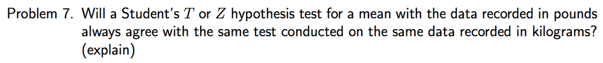

- Since the standard deviations are in the same units as the data collected, the true population standard deviation units of a $Z$ test or the sample standard deviation units in a T-test will cancel with the units of the given data. **Therefore, the T and Z test statistics are unit-less.** As a result, **the units on certain data will not affect the outcome of the test and will give the same test statistics**.
- Example: we have data $X_1,\ldots,X_n$ measured in kilograms with mean and variance $\mu_{X}$, $\sigma^2_{X}$. If we let $Y_1,\ldots,Y_n$ be the same data data expressed in pounds, then

$$\begin{aligned}
Y_i & = 2.2 \cdot X_i \\
\overline{Y}_n & = 2.2 \cdot \overline{X}_n \\
var(Y) & = (2.22)^2 \cdot \sigma^2_{X} \\
sd(Y) & = 2.22 \cdot \sigma_{X} \\
TS &= \frac{\overline{Y}_n - \mu_Y}{sd(Y)/\sqrt{n}} = \frac{2.2 \cdot \overline{X}_n - 2.2 \cdot \mu_X}{2.22 \cdot sd(X)/\sqrt{n}} = \frac{\overline{X}_n - \mu_X}{ sd(X)/\sqrt{n}}
\end{aligned}$$

## HW5 Problem 8

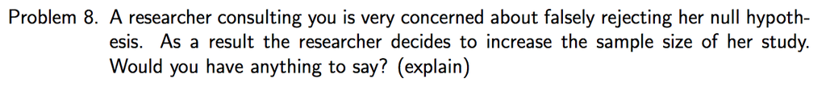

- An increase in sample size generally will make a study more powerful to detect a difference if one truly exists, but will not shield against false rejection of the null hypothesis (is other words, will not protect from rejecting null hypothesis if there is no difference).
- The **significance level $\alpha$ is the probability of falsely rejecting null hypothesis**, so if a researcher is concerned about falsely rejecting her null hypothesis, she should lower $\alpha$.

## HW5 Problem 10

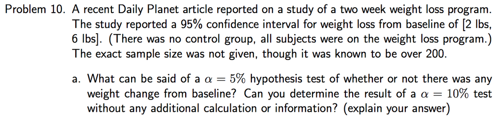

- Recall that the definition of a p-value is the probability of seeing a test statistic as or more extreme than the one you obseve, given your null hypothesis.
- If you reject the null hypothesis for $\alpha = 0.05$, this implies the probability of seeing a test statistic as or more extreme than the one you observe is less than $0.05$. It follows immediately that this probability is also less than $0.1$, leading us to reject the null hypothesis for $\alpha = 0.1$ whenever we reject for $\alpha = 0.05$.